# Building the Dream Chicago Bulls NBA Team

Arulnesan Arunan U3234570

09/05/2023

# 1. Introduction:

## Basketball Background Information:

Basketball is a fast-paced physical sport, that requires players with unique skill set at each position to reach the highest level. There are five main positions in a team to begin with:

- Point Guard
- Shooting Guard
- Small Forward
- Power Forward
- Centre

Each of the five positions on a basketball team has its unique requirements, with point guards typically focusing on ball-handling and play making, shooting guards on scoring, small forwards on versatility, power forwards on rebounding and interior scoring, and centres on defence and shot-blocking.

In the context of the given assignment, the following key metrics are important to the positions as follows, idea behind it being the possibility of a player performing in multiple roles.

- For a PG: Any 2 of Passing/ Shooting/Defence
- For a SG: Any 2 of Passing/ Shooting/Defence
- For a SF: Any 2 of Passing/Shooting/Defence
- For a PF: Any 2 of Passing/Rebound/Defence
- For a Centre: Any 2 of Rebound/Defence/Shooting

While building a team, if we try to reciprocate the above criteria the chances of the team achieving success increase exponentially. Balancing shooting with passing and defence is crucial in a team’s line-up. There is an iconic saying by Sir Alex Ferguson in English Football: ATTACK WINS GAMES, DEFENCE WINS TITLES. This can be applied to the game of basketball as well.

## Description of Scenario:

To complete this task, a thorough analysis of the players on the team and potential players from outside the team. The analysis took into account their performance in the previous season, their strengths and weaknesses, their fit within the team’s playing style and their value for money.

The repository contains a reproducible data analysis project and a generated knitr report using R Markdown. This report includes details of the analysis process, the selection criteria for the starting five players, and the performance metrics used to evaluate each player. Specific player recommendations for the team within the budget has also been provided.

## Project Aim:

The main of the project is to build a starting line-up for Chicago Bulls in the 2019-20 NBA season with the given salary cap, while leaving a room for accommodating the bench players as well to achieve maximum results.

## d) justification and importance

The project involves selecting one player for each position, ensuring their combined salaries do not exhaust the entire budget, and proving their value to the team. The project will involve analysing players’ performances based on key metrics, evaluating their fit within the team’s playstyle, and determining the most cost-effective options. A team can sign 2-3 players with more value, but the rest of the players can be signed with minimum contracts such as Veteran minimum contract, Rookie contract, etc., as long as they can to adapt to the team in delivering performance to the maximum extent with their skill set.

The justification and importance of this project lie in the potential impact of an optimized starting line-up on the team’s overall performance. By identifying the most valuable players within the budget constraints, the Chicago Bulls can enhance their competitiveness in the league and improve their chances of securing a higher standing in the 2019-20 season. This analysis will also provide valuable insights into the most effective strategies for allocating resources in a salary-capped professional sports league.

# 2. Reading and Cleaning Data:

Loading and understanding the data,

## Data set descriptions and variable descriptions

The datasets used are chosen for the below sources directly

1. 2018-19_nba_player-statistics.csv : sourced from basketball-reference.com
2. 2018-19_nba_player-salaries.csv : sourced from hoopshype.com/salaries
3. 2019-20_nba_team-payroll.csv : sourced from hoopshype.com/salaries
4. 2018-19_nba_team-statistics_1.csv : sourced from basketball-reference.com
5. 2018-19_nba_team-statistics_2.csv : sourced from basketball-reference.com

```r
### reading the dataframe
player_statistics <- read.csv("data/raw/2018-19_nba_player-statistics.csv")

### Viewing the dataframe and the top 5 rows of the data frame
# View(player_statistics)
head(player_statistics, 5)
```

```
##    player_name Pos Age  Tm  G GS   MP  FG FGA   FG. X3P X3PA  X3P. X2P X2PA
## 1 Alex Abrines  SG  25 OKC 31  2  588  56 157 0.357  41  127 0.323  15   30
## 2   Quincy Acy  PF  28 PHO 10  0  123   4  18 0.222   2   15 0.133   2    3
## 3 Jaylen Adams  PG  22 ATL 34  1  428  38 110 0.345  25   74 0.338  13   36
## 4 Steven Adams   C  25 OKC 80 80 2669 481 809 0.595   0    2 0.000 481  807
## 5  Bam Adebayo   C  21 MIA 82 28 1913 280 486 0.576   3   15 0.200 277  471
##    X2P.  eFG.  FT FTA   FT. ORB DRB TRB AST STL BLK TOV  PF  PTS
## 1 0.500 0.487  12  13 0.923   5  43  48  20  17   6  14  53  165
## 2 0.667 0.278   7  10 0.700   3  22  25   8   1   4   4  24   17
## 3 0.361 0.459   7   9 0.778  11  49  60  65  14   5  28  45  108
## 4 0.596 0.595 146 292 0.500 391 369 760 124 117  76 135 204 1108
## 5 0.588 0.579 166 226 0.735 165 432 597 184  71  65 121 203  729
```

```r
### Viewing the different data variables and data structures
# str(player_statistics)
```

```r
### reading the dataframe
player_salaries <- read.csv("data/raw/2018-19_nba_player-salaries.csv")

### Viewing the dataframe and the top 5 rows of the data frame
# View(player_salaries)
head(player_salaries, 5)
```

```
##   player_id  player_name   salary
## 1         1 Alex Abrines  3667645
## 2         2   Quincy Acy   213948
## 3         3 Steven Adams 24157304
## 4         4 Jaylen Adams   236854
## 5         5  Bam Adebayo  2955840
```

```r
### Viewing the different data variables and data structures
# str(player_salaries)
```

```r
### reading the dataframe
team_statistics_1 <- read.csv("data/raw/2018-19_nba_team-statistics_1.csv")

### Viewing the dataframe and the top 5 rows of the data frame
# View(team_statistics_1)
head(team_statistics_1, 5)
```

```
##   Rk                  Team  Age  W  L PW PL  MOV   SOS  SRS  ORtg  DRtg NRtg
## 1  1       Milwaukee Bucks 26.9 60 22 61 21 8.87 -0.82 8.04 113.8 105.2  8.6
## 2  2 Golden State Warriors 28.4 57 25 56 26 6.46 -0.04 6.42 115.9 109.5  6.4
## 3  3       Toronto Raptors 27.3 58 24 56 26 6.09 -0.60 5.49 113.1 107.1  6.0
## 4  4             Utah Jazz 27.3 50 32 54 28 5.26  0.03 5.28 110.9 105.7  5.2
## 5  5       Houston Rockets 29.2 53 29 53 29 4.77  0.19 4.96 115.5 110.7  4.8
##    Pace   FTr X3PAr   TS.  eFG. TOV. ORB. FT.FGA DRB.  X X.1 X.2
## 1 103.3 0.255 0.419 0.583 0.550 12.0 20.8  0.197 80.3 NA  NA  NA
## 2 100.9 0.227 0.384 0.596 0.565 12.6 22.5  0.182 77.1 NA  NA  NA
## 3 100.2 0.247 0.379 0.579 0.543 12.4 21.9  0.198 77.1 NA  NA  NA
## 4 100.3 0.295 0.394 0.572 0.538 13.4 22.9  0.217 80.3 NA  NA  NA
## 5  97.9 0.279 0.519 0.581 0.542 12.0 22.8  0.221 74.4 NA  NA  NA
```

```r
### Viewing the different data variables and data structures
# str(team_statistics_1)
```

```r
### reading the dataframe
team_statistics_2 <- read.csv("data/raw/2018-19_nba_team-statistics_2.csv")

### Viewing the dataframe and the top 5 rows of the data frame
# View(team_statistics_2)
head(team_statistics_2, 5)
```

```
##   Rk                  Team  G    MP   FG  FGA   FG.  X3P X3PA  X3P.  X2P X2PA
## 1  1       Milwaukee Bucks 82 19780 3555 7471 0.476 1105 3134 0.353 2450 4337
## 2  2 Golden State Warriors 82 19805 3612 7361 0.491 1087 2824 0.385 2525 4537
## 3  3  New Orleans Pelicans 82 19755 3581 7563 0.473  842 2449 0.344 2739 5114
## 4  4    Philadelphia 76ers 82 19805 3407 7233 0.471  889 2474 0.359 2518 4759
## 5  5  Los Angeles Clippers 82 19830 3384 7178 0.471  821 2118 0.388 2563 5060
##    X2P.   FT  FTA   FT. ORB  DRB  TRB  AST STL BLK  TOV   PF  PTS
## 1 0.565 1471 1904 0.773 762 3316 4078 2136 615 486 1137 1608 9686
## 2 0.557 1339 1672 0.801 797 2990 3787 2413 625 525 1169 1757 9650
## 3 0.536 1462 1921 0.761 909 2969 3878 2216 610 441 1215 1732 9466
## 4 0.529 1742 2258 0.771 892 3025 3917 2207 606 432 1223 1745 9445
## 5 0.507 1853 2340 0.792 796 2936 3732 1970 561 385 1193 1913 9442
```

```r
### Viewing the different data variables and data structures
# str(team_statistics_2)
```

```r
### reading the dataframe
team_payroll <- read.csv("data/raw/2019-20_nba_team-payroll.csv")

### Viewing the dataframe and the top 5 rows of the data frame
# View(team_payroll)
head(team_payroll, 5)
```

```
##   team_id           team        salary
## 1       1         Miami  $153,171,497
## 2       2  Golden State  $146,291,276
## 3       3 Oklahoma City  $144,916,427
## 4       4       Toronto  $137,793,831
## 5       5     Milwaukee  $130,988,604
```

```r
### Viewing the different data variables and data structures
# str(team_payroll)
```

# 3. Exploratory analysis

## a) checking for errors and missing values within the datasets

```r
if (sum(colSums(is.na(player_statistics)) > 0) >= 1) {
  print("The Variables with NAs in dataframe player_statistics are: ")
  print(names(subset(colSums(is.na(player_statistics)), colSums(is.na(player_statistics)) > 0)))
} else {
       print("No NAs in the dataframe player_statistics")
  }
```

```
## [1] "The Variables with NAs in dataframe player_statistics are: "
## [1] "FG."  "X3P." "X2P." "eFG." "FT."
```

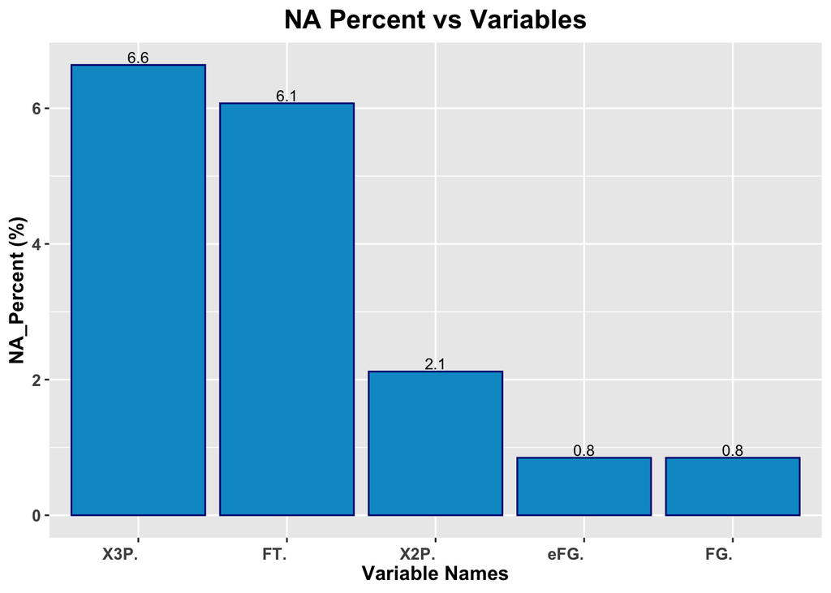

```r
### Plotting the NA Percentages for NA columns in player_statistics dataframe

na_summary_player_statistics <- player_statistics %>% gather(key = "Variable_Name", value = "Value", everything()) %>%
  group_by(Variable_Name) %>%
  summarise(NA_percent = sum(is.na(Value))/nrow(player_statistics)*100) %>%
  filter(NA_percent > 0) %>%
  arrange(desc(NA_percent)) %>%
  ggplot(mapping = aes(x=reorder(Variable_Name, -NA_percent), y=NA_percent))+
  geom_bar(stat = "Identity", fill = "deepskyblue3", color = "navy")+
  geom_text(aes(label = round(NA_percent,1)), vjust = -0.2, size = 3.3)+
  ggtitle("NA Percent vs Variables")+
  xlab("Variable Names")+
  ylab("NA_Percent (%)")+
  theme(plot.title = element_text(size = 16, face = "bold", hjust = 0.5),
        axis.title.x = element_text(size = 12, face = "bold", hjust = 0.5),
        axis.title.y = element_text(size = 12, face = "bold", hjust = 0.5),
        axis.text.y = element_text(size = 10, face = "bold", hjust = 0.5),
        axis.text.x = element_text(angle = 0, size = 10, face = "bold", hjust = 1, vjust = 0.5),
        legend.title = element_text(size = 10))

### Print na_summary plot
na_summary_player_statistics
```

Dealing with NAs in player_statistics dataframe.

```r
### printing the number of unique player names in player_statistics dataframe
length(unique(player_statistics$player_name))
```

```
## [1] 530
```

We can observe that player_statistics dataframe has 530 unique player names but where as overall there are 708 observations indicating duplicate names. The Duplicate names are due to the reason of players getting transfered or trading during the season.

To rectify this while inspecting the observations, the last duplicate name appears to have the cumulative metrics for that player during the season. Therefore a simple filtering using maximum number of players will give us the final metrics.

```r
### dealing with NA values in player_statistics
player_statistics_filtered <- player_statistics %>% group_by(player_name) %>% filter(G == max(G))

player_statistics_filtered
```

```
## # A tibble: 530 × 29
## # Groups:   player_name [530]
##    player_name Pos     Age Tm        G    GS    MP    FG   FGA   FG.   X3P  X3PA
##    <chr>       <chr> <int> <chr> <int> <int> <int> <int> <int> <dbl> <int> <int>
##  1 Alex Abrin… SG       25 OKC      31     2   588    56   157 0.357    41   127
##  2 Quincy Acy  PF       28 PHO      10     0   123     4    18 0.222     2    15
##  3 Jaylen Ada… PG       22 ATL      34     1   428    38   110 0.345    25    74
##  4 Steven Ada… C        25 OKC      80    80  2669   481   809 0.595     0     2
##  5 Bam Adebayo C        21 MIA      82    28  1913   280   486 0.576     3    15
##  6 Deng Adel   SF       21 CLE      19     3   194    11    36 0.306     6    23
##  7 DeVaughn A… SG       25 DEN       7     0    22     3    10 0.3       0     4
##  8 LaMarcus A… C        33 SAS      81    81  2687   684  1319 0.519    10    42
##  9 Rawle Alki… SG       21 CHI      10     1   120    13    39 0.333     3    12
## 10 Grayson Al… SG       23 UTA      38     2   416    67   178 0.376    32    99
## # … with 520 more rows, and 17 more variables: X3P. <dbl>, X2P <int>,
## #   X2PA <int>, X2P. <dbl>, eFG. <dbl>, FT <int>, FTA <int>, FT. <dbl>,
## #   ORB <int>, DRB <int>, TRB <int>, AST <int>, STL <int>, BLK <int>,
## #   TOV <int>, PF <int>, PTS <int>
```

```r
if (sum(colSums(is.na(player_statistics_filtered)) > 0) >= 1) {
  print("The Variables with NAs in dataframe player_statistics_filtered are: ")
  print(names(subset(colSums(is.na(player_statistics_filtered)), colSums(is.na(player_statistics_filtered)) > 0)))
} else {
       print("No NAs in the dataframe player_statistics_filtered")
  }
```

```
## [1] "The Variables with NAs in dataframe player_statistics_filtered are: "
## [1] "FG."  "X3P." "X2P." "eFG." "FT."
```

NA values still exist, all the columns seems to be calculation columns based on other variables. Checking if all the denominators for these calculations are Zero which is leading to NAs

```r
player_statistics_filtered %>% filter(!complete.cases(FG.)) %>% ungroup() %>%
  summarise(FGA_Denominator_Sum = sum(FGA))
```

```
## # A tibble: 1 × 1
##   FGA_Denominator_Sum
##                 <int>
## 1                   0
```

```r
player_statistics_filtered %>% filter(!complete.cases(X3P.)) %>% ungroup() %>%
  summarise(X3PA_Denominator_Sum = sum(X3PA))
```

```
## # A tibble: 1 × 1
##   X3PA_Denominator_Sum
##                  <int>
## 1                    0
```

```r
player_statistics_filtered %>% filter(!complete.cases(X2P.)) %>% ungroup() %>%
  summarise(X2PA_Denominator_Sum = sum(X2PA))
```

```
## # A tibble: 1 × 1
##   X2PA_Denominator_Sum
##                  <int>
## 1                    0
```

```r
player_statistics_filtered %>% filter(!complete.cases(eFG.)) %>% ungroup() %>%
  summarise(FGA_Denominator_Sum = sum(FGA))
```

```
## # A tibble: 1 × 1
##   FGA_Denominator_Sum
##                 <int>
## 1                   0
```

```r
player_statistics_filtered %>% filter(!complete.cases(FT.)) %>% ungroup() %>%
  summarise(FT_Denominator_Sum = sum(FT))
```

```
## # A tibble: 1 × 1
##   FT_Denominator_Sum
##                <int>
## 1                  0
```

The denominators are causing the NAs in th player_statistics_filtered dataframe imputing the NAs with Zeros will be an appropriate measure.

```r
### imputing with Zero
player_statistics_filtered <- replace(player_statistics_filtered, is.na(player_statistics_filtered), 0)

### Checking NAs again
if (sum(colSums(is.na(player_statistics_filtered)) > 0) >= 1) {
  print("The Variables with NAs in dataframe player_statistics_filtered are: ")
  print(names(subset(colSums(is.na(player_statistics_filtered)), colSums(is.na(player_statistics_filtered)) > 0)))
} else {
       print("No NAs in the dataframe player_statistics_filtered")
  }
```

```
## [1] "No NAs in the dataframe player_statistics_filtered"
```

```r
if (sum(colSums(is.na(player_salaries)) > 0) >= 1) {
  print("The Variables with NAs in dataframe player_salaries are: ")
  print(names(subset(colSums(is.na(player_salaries)), colSums(is.na(player_salaries)) > 0)))
} else {
       print("No NAs in the dataframe player_salaries")
  }
```

```
## [1] "No NAs in the dataframe player_salaries"
```

```r
if (sum(colSums(is.na(team_statistics_1)) > 0) >= 1) {
  print("The Variables with NAs in dataframe team_statistics_1 are: ")
  print(names(subset(colSums(is.na(team_statistics_1)), colSums(is.na(team_statistics_1)) > 0)))
} else {
       print("No NAs in the dataframe team_statistics_1")
  }
```

```
## [1] "The Variables with NAs in dataframe team_statistics_1 are: "
## [1] "X"   "X.1" "X.2"
```

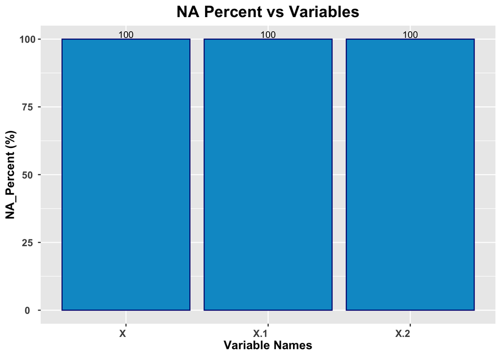

```r
### Plotting the NA Percentages for NA columns in team_statistics_1 dataframe

na_summary_team_statistics_1 <- team_statistics_1 %>% gather(key = "Variable_Name", value = "Value", everything()) %>%
  group_by(Variable_Name) %>%
  summarise(NA_percent = sum(is.na(Value))/nrow(team_statistics_1)*100) %>%
  filter(NA_percent > 0) %>%
  arrange(desc(NA_percent)) %>%
  ggplot(mapping = aes(x=reorder(Variable_Name, -NA_percent), y=NA_percent))+
  geom_bar(stat = "Identity", fill = "deepskyblue3", color = "navy")+
  geom_text(aes(label = round(NA_percent,1)), vjust = -0.2, size = 3.3)+
  ggtitle("NA Percent vs Variables")+
  xlab("Variable Names")+
  ylab("NA_Percent (%)")+
  theme(plot.title = element_text(size = 16, face = "bold", hjust = 0.5),
        axis.title.x = element_text(size = 12, face = "bold", hjust = 0.5),
        axis.title.y = element_text(size = 12, face = "bold", hjust = 0.5),
        axis.text.y = element_text(size = 10, face = "bold", hjust = 0.5),
        axis.text.x = element_text(angle = 0, size = 10, face = "bold", hjust = 1, vjust = 0.5),
        legend.title = element_text(size = 10))

### Print na_summary plot
na_summary_team_statistics_1
```

As these are full columns and upon inspecting these are the last three columns. They can simply be removed through slicing.

```r
### dealing with NA values in team_statistics_1 , selecting only the columns without NAs
team_statistics_1 <- team_statistics_1 %>% select(Rk:DRB.)

### Checking NAs again
if (sum(colSums(is.na(team_statistics_1)) > 0) >= 1) {
  print("The Variables with NAs in dataframe team_statistics_1 are: ")
  print(names(subset(colSums(is.na(team_statistics_1)), colSums(is.na(team_statistics_1)) > 0)))
} else {
       print("No NAs in the dataframe team_statistics_1")
  }
```

```
## [1] "No NAs in the dataframe team_statistics_1"
```

```r
if (sum(colSums(is.na(team_statistics_2)) > 0) >= 1) {
  print("The Variables with NAs in dataframe team_statistics_2 are: ")
  print(names(subset(colSums(is.na(team_statistics_2)), colSums(is.na(team_statistics_2)) > 0)))
} else {
       print("No NAs in the dataframe team_statistics_2")
  }
```

```
## [1] "No NAs in the dataframe team_statistics_2"
```

```r
if (sum(colSums(is.na(team_payroll)) > 0) >= 1) {
  print("The Variables with NAs in dataframe team_payroll are: ")
  print(names(subset(colSums(is.na(team_payroll)), colSums(is.na(team_payroll)) > 0)))
} else {
       print("No NAs in the dataframe team_payroll")
  }
```

```
## [1] "No NAs in the dataframe team_payroll"
```

Merging the dataframes of salary and statistics together.

```r
### adding player salaries to player statistics data frame
player_statistics_salary_combined <- merge(player_statistics_filtered, player_salaries, by = 'player_name')
```

As team payroll dataframe’s salary colum is of data type character, converting it to numeric.

```r
### converting the team_payroll salary column to a numeric variable
team_payroll$salary <- as.numeric(gsub("[//$,]", "", team_payroll$salary))
```

Writing all the dataframes to processed folder

```r
### writing dataframes to processed folder inside data folder

write_csv(player_statistics_salary_combined,
          file = "data/processed/player_statistics_salary.csv")

write_csv(team_payroll,
          file = "data/processed/team_payroll.csv")
```

All other dataframes were free from error.

```r
### Checking NAs again

if (sum(colSums(is.na(player_statistics_salary_combined)) > 0) >= 1) {
  print("The Variables with NAs in dataframe player_statistics_salary_combined are: ")
  print(names(subset(colSums(is.na(player_statistics_salary_combined)), colSums(is.na(player_statistics_salary_combined)) > 0)))
} else {
       print("No NAs in the dataframe player_statistics_salary_combined")
  }
```

```
## [1] "No NAs in the dataframe player_statistics_salary_combined"
```

## b) checking the distribution of variables

### NBA Player Salary Distribution

Firstly checking the salary distribution of NBA players.

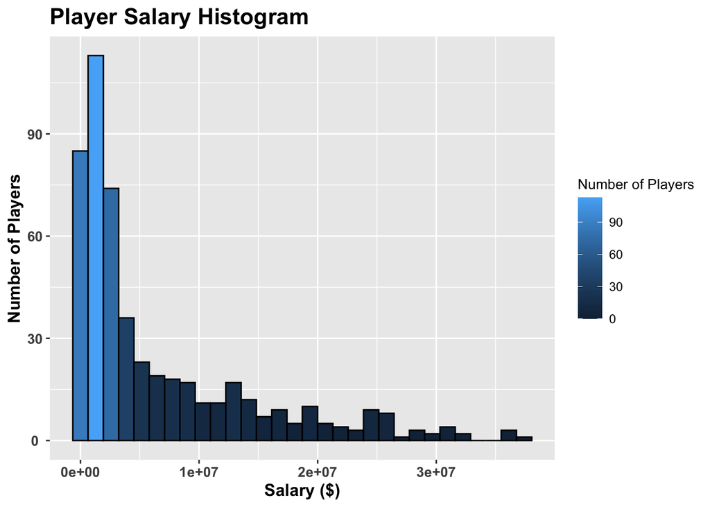

```r
### Plotting the distribution of Player Salaries
salary_histogram <- player_statistics_salary_combined %>%
  ggplot(mapping = aes(salary, fill = ..count..))+
  geom_histogram(color = "black")+
  scale_fill_continuous(name = "Number of Players")+
  ylab("Number of Players")+
  xlab("Salary ($)")+
  ggtitle("Player Salary Histogram")+
  theme(plot.title = element_text(size = 16, face = "bold", hjust = 0),
        axis.title.x = element_text(size = 12, face = "bold", hjust = 0.5),
        axis.title.y = element_text(size = 12, face = "bold", hjust = 0.5),
        axis.text.y = element_text(size = 10, face = "bold", hjust = 0.5),
        axis.text.x = element_text(angle = 0, size = 10, face = "bold", hjust = 0.5, vjust = 1),
        legend.title = element_text(size = 10))

### Printing the Player Salary Histogram to Screen
salary_histogram
```

We can observe that the distribution is skewed to the right due to few excellent players. This is a usual observance for a monetary variable describing prices/value/salary. Eg. Housing Prices do show a similar distribution.

### NBA Teams Payroll Distribution (Histogram)

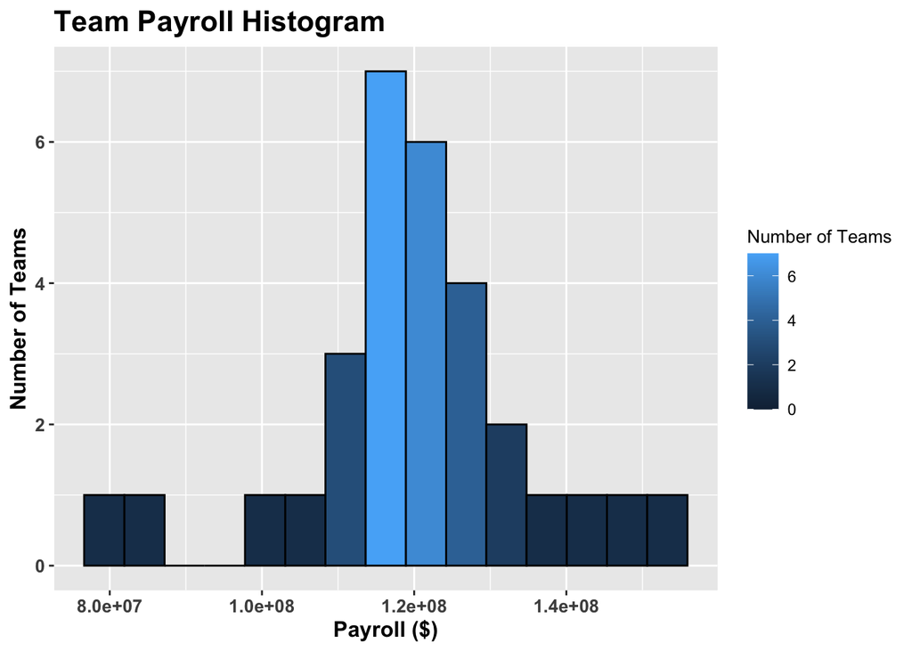

```r
### Plotting the distribution of Team Payroll
team_payroll_histogram <- team_payroll %>%
  ggplot(mapping = aes(salary, fill = ..count..))+
  geom_histogram(color = "black", bins = 15)+
  scale_fill_continuous(name = "Number of Teams")+
  ylab("Number of Teams")+
  xlab("Payroll ($)")+
  ggtitle("Team Payroll Histogram")+
  theme(plot.title = element_text(size = 16, face = "bold", hjust = 0),
        axis.title.x = element_text(size = 12, face = "bold", hjust = 0.5),
        axis.title.y = element_text(size = 12, face = "bold", hjust = 0.5),
        axis.text.y = element_text(size = 10, face = "bold", hjust = 0.5),
        axis.text.x = element_text(angle = 0, size = 10, face = "bold", hjust = 0.5, vjust = 1),
        legend.title = element_text(size = 10))

### Printing the Team Payroll Histogram to Screen
team_payroll_histogram
```

We can observe that the histogram for team payrolls are normally distributed indicating a fair competition.

### NBA Teams Payroll Bar Charts

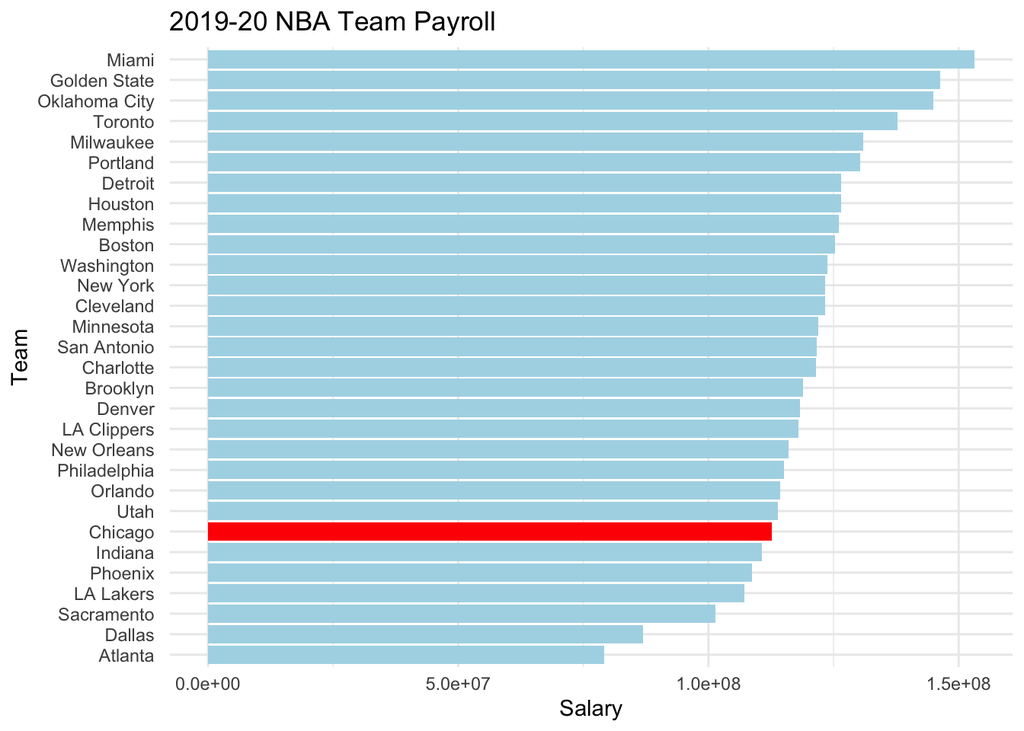

```r
# Sort data frame in descending order of salary and add a new column called "highlight"
team_payroll_sorted <- team_payroll %>%
  arrange(desc(salary)) %>%
  mutate(highlight = ifelse(team == "Chicago ", "red", "lightblue"))

# Create ggplot2 visualization
ggplot(team_payroll_sorted, aes(x = reorder(team, salary), y = salary, fill = highlight)) +
  geom_bar(stat = "identity") +
  coord_flip() +
  labs(x = "Team", y = "Salary", title = "2019-20 NBA Team Payroll") +
  theme_minimal() +
  scale_fill_identity(guide = FALSE)
```

We can observe that Chicago Bulls are near the bottom with respect to payroll budgets. This indicates that its at a disadvantage and therefore it needs to be out of the box with respect to player recruitment.

### NBA Player Age Distribution

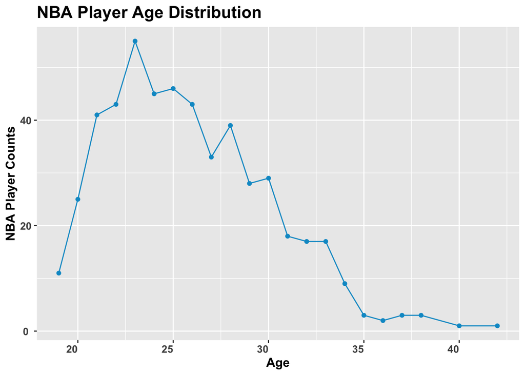

```r
### age distribution
age_distribution_plot <- player_statistics_salary_combined %>% group_by(Age) %>%
  summarise(Count = n()) %>%
  ggplot(mapping = aes(x = Age, y = Count))+
  geom_line(color = "deepskyblue3")+
  geom_point(color = "deepskyblue3")+
  ggtitle("NBA Player Age Distribution")+
  ylab("NBA Player Counts")+
  xlab("Age")+
  theme(plot.title = element_text(size = 16, face = "bold", hjust = 0),
        axis.title.x = element_text(size = 12, face = "bold", hjust = 0.5),
        axis.title.y = element_text(size = 12, face = "bold", hjust = 0.5),
        axis.text.y = element_text(size = 10, face = "bold", hjust = 0.5),
        axis.text.x = element_text(angle = 0, size = 10, face = "bold", hjust = 1, vjust = 1),
        legend.title = element_text(size = 10))



### Print median_building_type_house_price_yearly plot
age_distribution_plot
```

### NBA Player Playing Positions Count Distribution

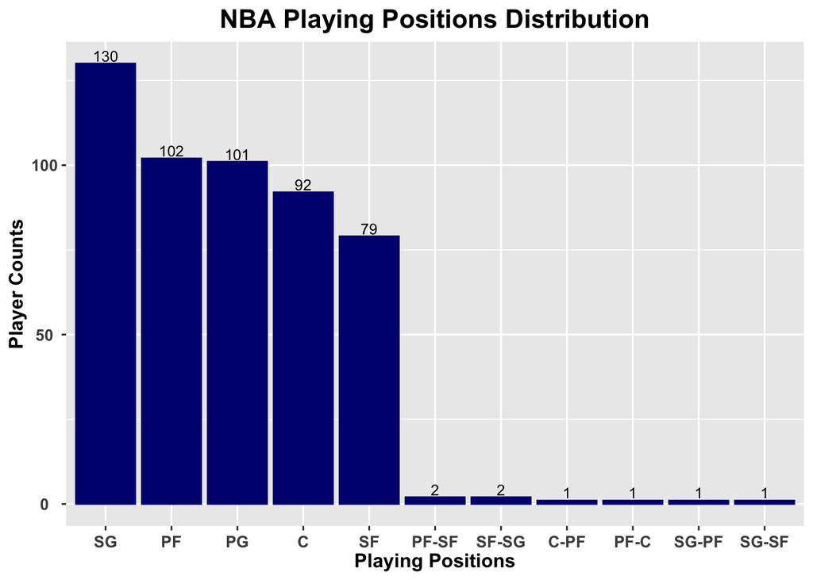

```r
### Playing Position Counts

playing_positions_distributionn_plot <- player_statistics_salary_combined %>% group_by(Pos) %>%
  summarise(Count = n()) %>%
  ggplot(mapping = aes(x=reorder(Pos, -Count), y=Count))+
  geom_bar(stat = "Identity", fill = "navy", color = "navy")+
  geom_text(aes(label = Count), vjust = -0.2, size = 3.3)+
  ggtitle("NBA Playing Positions Distribution")+
  xlab("Playing Positions")+
  ylab("Player Counts")+
  theme(plot.title = element_text(size = 16, face = "bold", hjust = 0.5),
        axis.title.x = element_text(size = 12, face = "bold", hjust = 0.5),
        axis.title.y = element_text(size = 12, face = "bold", hjust = 0.5),
        axis.text.y = element_text(size = 10, face = "bold", hjust = 0.5),
        axis.text.x = element_text(angle = 0, size = 10, face = "bold", hjust = 0.5, vjust = 0.5),
        legend.title = element_text(size = 10))


playing_positions_distributionn_plot
```

### Playing Postions Age Distributions

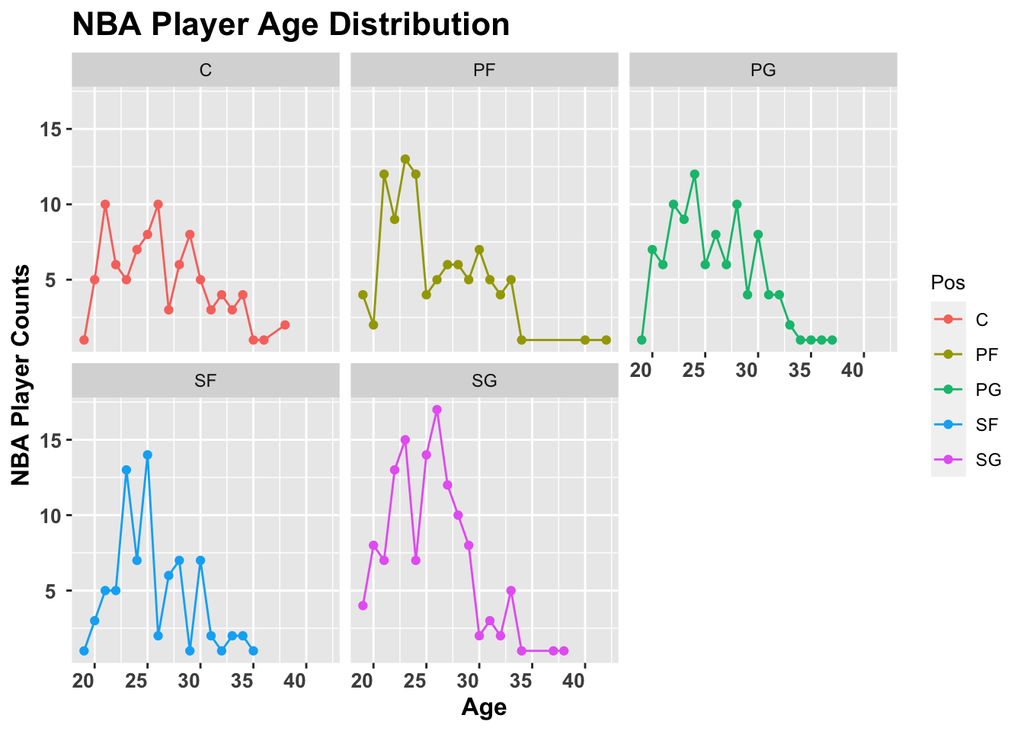

```r
### Playing Positions and Age Distributions
playing_positions_age_distribution_plot <- player_statistics_salary_combined %>%
  filter(Pos %in% c("SG", "PF", "PG", "C", "SF")) %>%
  group_by(Age, Pos) %>%
  summarise(Count = n()) %>%
  ggplot(mapping = aes(x = Age, y = Count, color = Pos))+
  geom_line()+
  geom_point()+
  ggtitle("NBA Player Age Distribution")+
  ylab("NBA Player Counts")+
  xlab("Age")+
  facet_wrap(~Pos, nrow = 2)+
  theme(plot.title = element_text(size = 16, face = "bold", hjust = 0),
        axis.title.x = element_text(size = 12, face = "bold", hjust = 0.5),
        axis.title.y = element_text(size = 12, face = "bold", hjust = 0.5),
        axis.text.y = element_text(size = 10, face = "bold", hjust = 0.5),
        axis.text.x = element_text(angle = 0, size = 10, face = "bold", hjust = 1, vjust = 1),
        legend.title = element_text(size = 10))

### Print median_building_type_house_price_yearly plot
playing_positions_age_distribution_plot
```

### Distribution of Positionwise Mean Points Scored

This distribution will show us which playing position is on average contributing the highest.

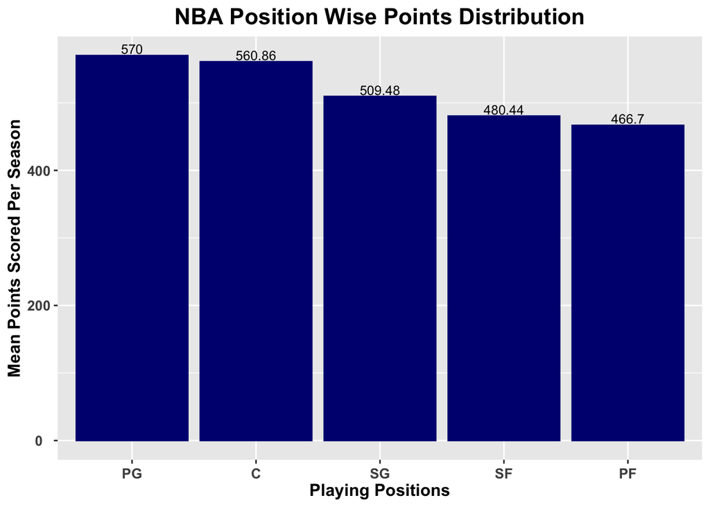

```r
### Position Wise Points Scored

position_points_distribution_plot <- player_statistics_salary_combined %>%
  filter(Pos %in% c("SG", "PF", "PG", "C", "SF")) %>%
  group_by(Pos) %>%
  summarise(Mean_Points = round(mean(PTS),2)) %>%
  ggplot(mapping = aes(x=reorder(Pos, -Mean_Points), y=Mean_Points))+
  geom_bar(stat = "Identity", fill = "navy", color = "navy")+
  geom_text(aes(label = Mean_Points), vjust = -0.2, size = 3.3)+
  ggtitle("NBA Position Wise Points Distribution")+
  xlab("Playing Positions")+
  ylab("Mean Points Scored Per Season")+
  theme(plot.title = element_text(size = 16, face = "bold", hjust = 0.5),
        axis.title.x = element_text(size = 12, face = "bold", hjust = 0.5),
        axis.title.y = element_text(size = 12, face = "bold", hjust = 0.5),
        axis.text.y = element_text(size = 10, face = "bold", hjust = 0.5),
        axis.text.x = element_text(angle = 0, size = 10, face = "bold", hjust = 0.5, vjust = 0.5),
        legend.title = element_text(size = 10))



position_points_distribution_plot
```

### c) checking for relationships between variables, or differences between groups

```r
### filtering the top 3 ranked teams to identify the best teams metrics
team_statistics_2 %>% filter(Rk == c(1,2,3)) %>% select(c(Rk, Team, FG., X3P., X2P., FT., PF, PTS))
```

```
##   Rk                  Team   FG.  X3P.  X2P.   FT.   PF  PTS
## 1  1       Milwaukee Bucks 0.476 0.353 0.565 0.773 1608 9686
## 2  2 Golden State Warriors 0.491 0.385 0.557 0.801 1757 9650
## 3  3  New Orleans Pelicans 0.473 0.344 0.536 0.761 1732 9466
```

We can see that Golden State Warriors had a better shooting record than Milwaukee Bucks.

```r
### looking at the best players from the best teams
player_statistics_salary_combined %>% filter(Tm %in% c("MIL", "GSW", "ORL")) %>% select(c(player_name, Tm, Pos, FG., X3P., X2P., FT., PF, PTS)) %>% arrange(desc(PTS))
```

```
##              player_name  Tm Pos   FG.  X3P.  X2P.   FT.  PF  PTS
## 1           Kevin Durant GSW  SF 0.521 0.353 0.587 0.885 155 2027
## 2  Giannis Antetokounmpo MIL  PF 0.578 0.256 0.641 0.729 232 1994
## 3          Stephen Curry GSW  PG 0.472 0.437 0.525 0.916 166 1881
## 4          Klay Thompson GSW  SG 0.467 0.402 0.516 0.816 157 1680
## 5         Nikola Vucevic ORL   C 0.518 0.364 0.549 0.789 157 1665
## 6        Khris Middleton MIL  SF 0.441 0.378 0.485 0.837 172 1407
## 7           Aaron Gordon ORL  PF 0.449 0.349 0.499 0.731 172 1246
## 8           Eric Bledsoe MIL  PG 0.484 0.329 0.582 0.750 156 1241
## 9          Evan Fournier ORL  SG 0.438 0.340 0.509 0.806 225 1226
## 10         Terrence Ross ORL  SG 0.428 0.383 0.484 0.875 119 1223
## 11           Brook Lopez MIL   C 0.452 0.365 0.613 0.842 189 1009
## 12       Malcolm Brogdon MIL  SG 0.505 0.426 0.544 0.928 102 1001
## 13           DJ Augustin ORL  PG 0.470 0.421 0.511 0.866 115  948
## 14        Jonathan Isaac ORL  PF 0.429 0.323 0.510 0.815 143  720
```

[output cut: 33 more lines]

we can see that overall points of 9686 was scored by the championship team Milwaukee Bucks. We can also notice that they had significantly less personal fouls Even though Golden State had better FG. they were close second. Overall highest points doesn’t ensure a championship however scoring the most points is an indication of a very good team

We’ll explore the relationship for Points and identify its explanatory main variables We’ll perform a simple correlation plot to identify the most contributing variables expectations are for FG. , X3P., X2P. and FT. to have positive relationship with Points.

Based on a quick research following metrics are important,

- Scoring: A player’s ability to score points is one of the most important factors in their overall performance. This can be measured by factors such as points per game, shooting percentage, and usage rate.
- Rebounding: Rebounding is another important factor in a player’s overall performance. This includes both offensive and defensive rebounding, as well as the ability to create second-chance opportunities for their team.
- Defense: A player’s defensive abilities are also critical to their overall performance. This includes factors such as steals, blocks, and defensive rebounds, as well as their ability to guard opposing players effectively.
- Assists: Assists measure a player’s ability to create scoring opportunities for their teammates. A high number of assists can indicate that a player is an effective passer and facilitator on the court.
- Efficiency: Efficiency measures how effectively a player uses their possessions to contribute to their team’s success. This can be measured by factors such as field goal percentage, true shooting percentage, and player efficiency rating.
- Versatility: Players who are able to contribute in multiple areas of the game, such as scoring, rebounding, and defense, are highly valuable to their teams.

It’s important to note that no single factor can determine a player’s overall skill and performance. Rather, a combination of factors must be considered to assess a player’s overall value to their team.

Based on research it can be noted that maximizing the points per game can improve the chances of winning a championship factors such as, - FG. - X3P. - X2P. - FT. - TRB per game (TRBpG) - AST per game (ASTpG) - STL per game (STLpG) - BLK per game (BLKpG) - TOV per game (TOVpG) - PF per game (PFpG)

```r
### creating a separate dataframe for modelling variables
model_dataframe <- team_statistics_2 %>% group_by(Team) %>% mutate(PTSpG = PTS/G,
                                                                   TRBpG = TRB/G,
                                                                   ASTpG = AST/G,
                                                                   STLpG = STL/G,
                                                                   BLKpG = BLK/G,
                                                                   TOVpG = TOV/G,
                                                                   PFpG = PF/G) %>%
  ungroup() %>%
  select(PTSpG, FG., X3P., X2P., FT., TRBpG, ASTpG, STLpG, BLKpG, TOVpG, PFpG)
```

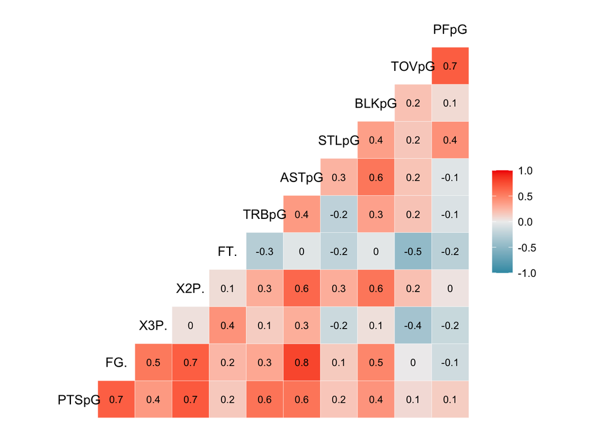

```r
### plotting the correlation plots
ggcorr(model_dataframe,
       label = TRUE,
       label_size = 3,
       hjust = 0.5)
```

We can see that FG. is highly correlated with other shooting metrics which form it.

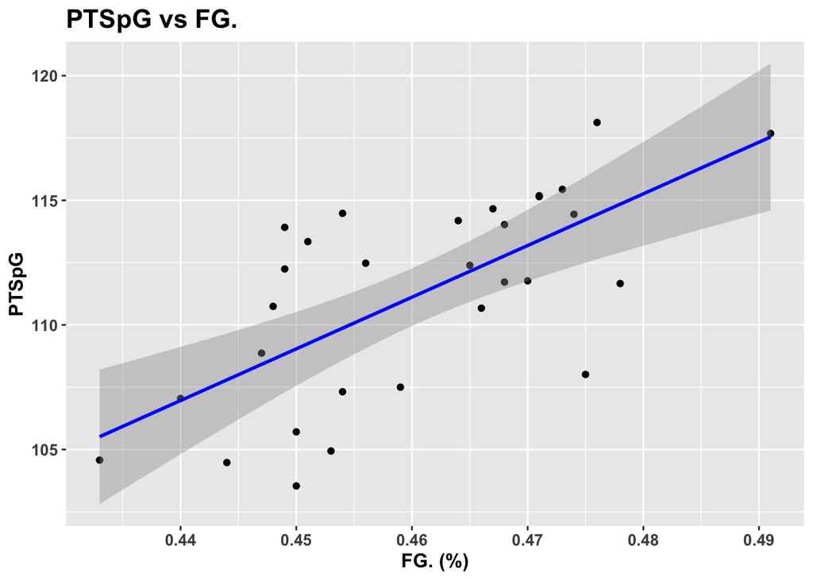

```r
### Inspecting the relationship between PTSpG and FG.
scatter_plot_PTSpG_vs_FG. <- model_dataframe %>% ggplot(mapping = aes(x=FG., y=PTSpG))+
  geom_point(alpha = 1)+
  geom_smooth(method = "lm", color = "blue")+
  scale_y_continuous(labels = scales::comma)+
  ylab("PTSpG")+
  xlab("FG. (%)")+
  ggtitle("PTSpG vs FG.")+
  theme(plot.title = element_text(size = 16, face = "bold", hjust = 0),
        axis.title.x = element_text(size = 12, face = "bold", hjust = 0.5),
        axis.title.y = element_text(size = 12, face = "bold", hjust = 0.5),
        axis.text.y = element_text(size = 10, face = "bold", hjust = 0.5),
        axis.text.x = element_text(angle = 0, size = 10, face = "bold", hjust = 0.5, vjust = 1),
        legend.title = element_text(size = 10))

### Print scatter_plot
scatter_plot_PTSpG_vs_FG.
```

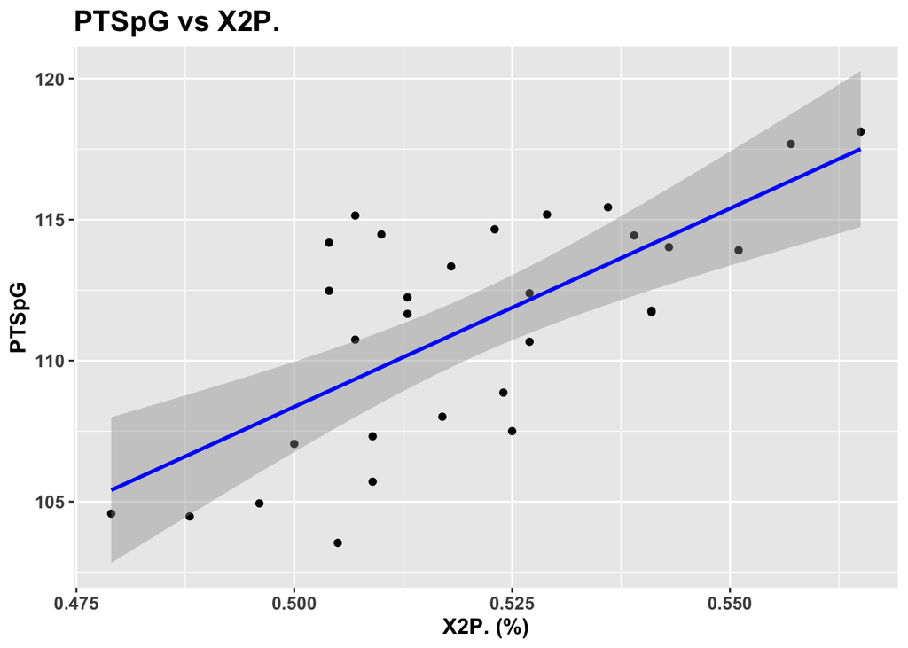

```r
### Inspecting the relationship between PTSpG and X2P.
scatter_plot_PTSpG_vs_X2P. <- model_dataframe %>% ggplot(mapping = aes(x=X2P., y=PTSpG))+
  geom_point(alpha = 1)+
  geom_smooth(method = "lm", color = "blue")+
  scale_y_continuous(labels = scales::comma)+
  ylab("PTSpG")+
  xlab("X2P. (%)")+
  ggtitle("PTSpG vs X2P.")+
  theme(plot.title = element_text(size = 16, face = "bold", hjust = 0),
        axis.title.x = element_text(size = 12, face = "bold", hjust = 0.5),
        axis.title.y = element_text(size = 12, face = "bold", hjust = 0.5),
        axis.text.y = element_text(size = 10, face = "bold", hjust = 0.5),
        axis.text.x = element_text(angle = 0, size = 10, face = "bold", hjust = 0.5, vjust = 1),
        legend.title = element_text(size = 10))

### Print scatter_plot
scatter_plot_PTSpG_vs_X2P.
```

We can see that both are showing a similar pattern which might indicate confounding problem.

# 4. Data modelling and results

## a) data modelling (e.g. creating a linear regression)

### Methodology

- The approach to be followed is to use the teams data to build a model to predict the points per game
- The built model will then be tested for multiple linear model assumptions
- Any dataset corrections will be made and then model will be refit and the failed assumptions will be checked again
- Once the final model which satisfies assumptions are produced. Team player metrics will be used to predict expected points per player.
- Then the model output dataframe will be filtered and using the predicted expected points per player, salary and one other position specific metric. The common intersection of players will be found and then chosen for the Chicago Bulls Team accordingly.

```r
### Building a multiple linear model for PTSpG
fit <- lm(PTSpG ~ FG.+X3P.+X2P.+FT.+TRBpG+ASTpG+STLpG+BLKpG+TOVpG+PFpG, data = model_dataframe)

### Viewing the model results
tidy(fit, conf.int = TRUE)
```

```
## # A tibble: 11 × 7
##    term        estimate std.error statistic  p.value  conf.low conf.high
##    <chr>          <dbl>     <dbl>     <dbl>    <dbl>     <dbl>     <dbl>
##  1 (Intercept) -57.2       23.2      -2.46  0.0236   -106.        -8.56
##  2 FG.          36.7       69.0       0.531 0.601    -108.       181.
##  3 X3P.         35.3       41.3       0.854 0.404     -51.2      122.
##  4 X2P.         98.9       30.5       3.25  0.00425    35.1      163.
##  5 FT.          28.8       16.9       1.71  0.104      -6.52      64.1
##  6 TRBpG         1.15       0.244     4.73  0.000147    0.642      1.66
##  7 ASTpG         0.0651     0.333     0.195 0.847      -0.633      0.763
##  8 STLpG         0.796      0.716     1.11  0.280      -0.703      2.30
##  9 BLKpG        -1.06       0.699    -1.52  0.145      -2.53       0.399
## 10 TOVpG        -0.834      0.729    -1.14  0.267      -2.36       0.692
## 11 PFpG          1.09       0.530     2.05  0.0545     -0.0231     2.20
```

```r
summary(fit)
```

```
##
## Call:
## lm(formula = PTSpG ~ FG. + X3P. + X2P. + FT. + TRBpG + ASTpG +
##     STLpG + BLKpG + TOVpG + PFpG, data = model_dataframe)
##
## Residuals:
##     Min      1Q  Median      3Q     Max
## -2.7599 -1.0535 -0.0865  1.0905  3.1854
##
## Coefficients:
##              Estimate Std. Error t value Pr(>|t|)
## (Intercept) -57.15175   23.21376  -2.462 0.023550 *
## FG.          36.67647   69.04978   0.531 0.601463
## X3P.         35.29001   41.33734   0.854 0.403902
## X2P.         98.93024   30.48020   3.246 0.004254 **
## FT.          28.78455   16.86659   1.707 0.104188
## TRBpG         1.15158    0.24366   4.726 0.000147 ***
## ASTpG         0.06512    0.33339   0.195 0.847211
## STLpG         0.79644    0.71625   1.112 0.280032
## BLKpG        -1.06308    0.69861  -1.522 0.144554
## TOVpG        -0.83409    0.72896  -1.144 0.266745
## PFpG          1.08600    0.52992   2.049 0.054490 .
## ---
## Signif. codes:  0 '***' 0.001 '**' 0.01 '*' 0.05 '.' 0.1 ' ' 1
##
## Residual standard error: 1.982 on 19 degrees of freedom
## Multiple R-squared:  0.8463, Adjusted R-squared:  0.7654
## F-statistic: 10.46 on 10 and 19 DF,  p-value: 8.772e-06
```

However overall the model has 0.7654 adj R-squared which indicates the combined explanatory power for PTSpG

## b) Checking For Model Assumptions

**Assumptions** The response variable should be continuous (i.e. ratio/interval) There are two or more explanatory variables that are either continuous or categorical There should be independence of observations There should be a linear relationship between the response variable and each explanatory variable There should be no significant outliers, influential or high leverage points The data needs to show homoscedasticity The residuals should be normally distributed There should not be multicollinearity between the explanatory variables

### Independence

```r
car::durbinWatsonTest(fit)
```

```
##  lag Autocorrelation D-W Statistic p-value
##    1        0.111937      1.656126   0.282
##  Alternative hypothesis: rho != 0
```

Residuals are not autocorrelated with the DW test the results are 1.65, which is close to the recommended 2 to ensure independence. Thus we have not failed this assumption.

### Outliers

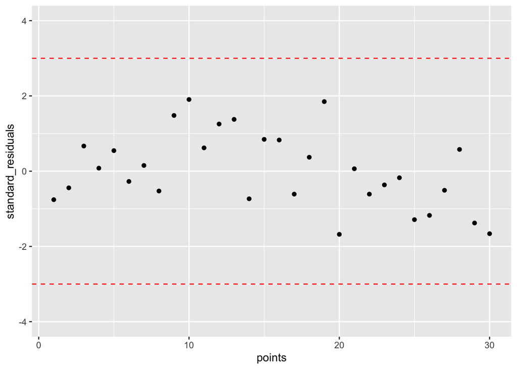

```r
# residuals computation
standard_residuals <- rstandard(fit)
points <- 1:length(standard_residuals)

ggplot(data = NULL, aes(x = points, y = standard_residuals)) +
  geom_point() +
  ylim(c(-4,4)) +
  geom_hline(yintercept = c(-3, 3), colour = "red", linetype = "dashed")
```

We can observe that most observations are within the norm. therefore there are no outliers.

### Leverage points

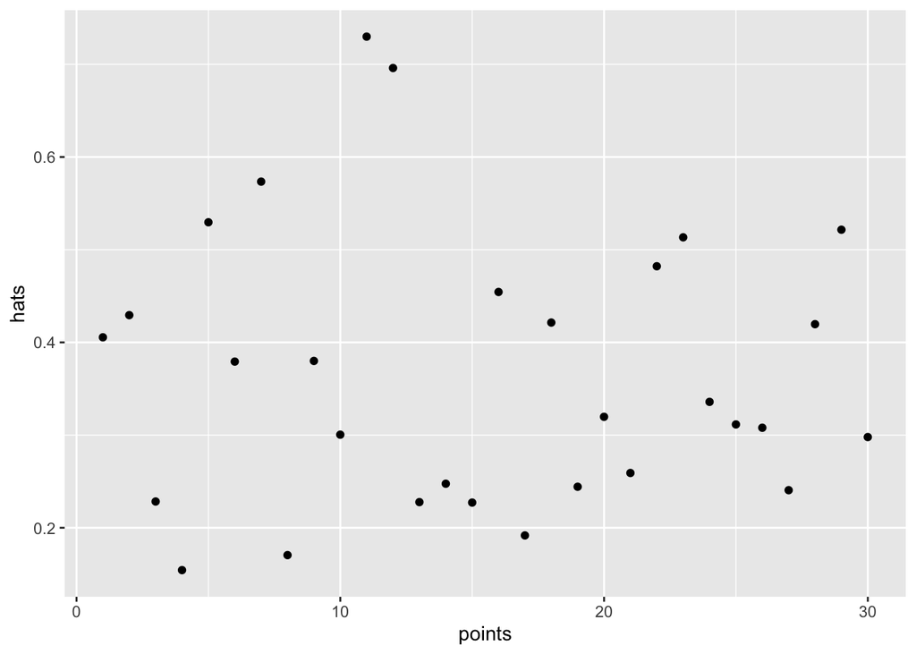

```r
### computing hat values and plotting
hats <- hatvalues(fit)

ggplot(data = NULL, aes(x = points, y = hats)) +
  geom_point()
```

there are no hatvalues greater than 1, however we might investigate the points above 0.6 as they seem to stick out above the rest.

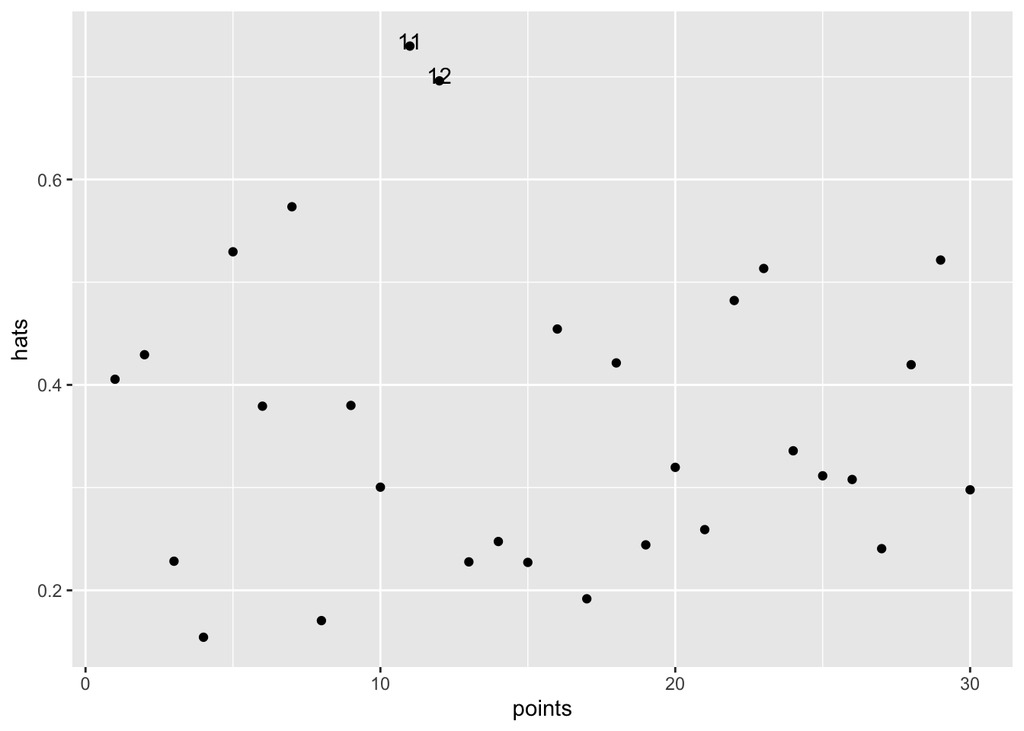

```r
### labelling the hat values
hat_labels <- if_else(hats >= 0.6, paste(points), "")

ggplot(data = NULL, aes(x = points, y = hats)) +
  geom_point() +
  geom_text(aes(label = hat_labels), nudge_y = 0.005)
```

The 11th and 12th observations are leverage points

### Influential points

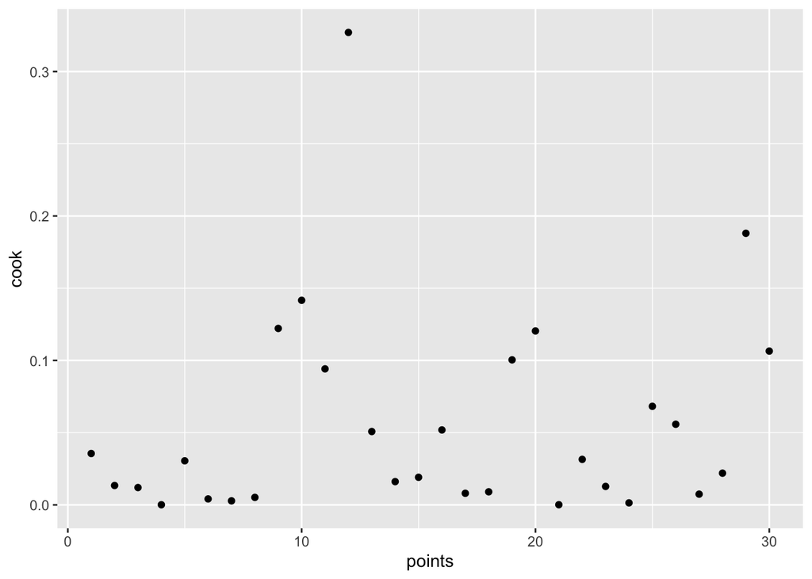

```r
### computing cook distance and plotting
cook <- cooks.distance(fit)

ggplot(data = NULL, aes(x = points, y = cook)) +
  geom_point()
```

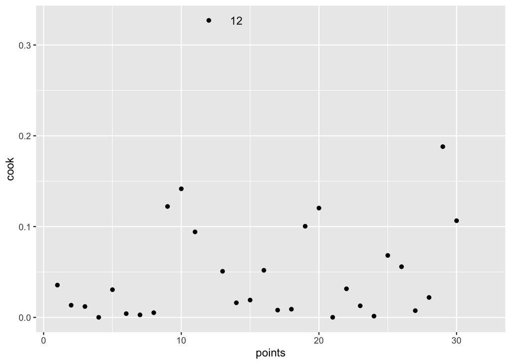

```r
### labelling the influential points
cook_labels <- if_else(cook >= 0.2, paste(points), "")

ggplot(data = NULL, aes(x = points, y = cook)) +
  geom_point() +
  geom_text(aes(label = cook_labels), nudge_x = 2)
```

Again obseravtion point 12 is repeated

```r
### removing the 11th and 12th observations from the model dataframe
filtered_model_dataframe <- model_dataframe[-c(11:12),]
```

Building a new model with the removed points to check for any improvements

```r
### Building the second multiple linear model for PTSpG
fit_2 <- lm(PTSpG ~ FG.+X3P.+X2P.+FT.+TRBpG+ASTpG+STLpG+BLKpG+TOVpG+PFpG, data = filtered_model_dataframe)

### viewing the summary results
summary(fit_2)
```

```
##
## Call:
## lm(formula = PTSpG ~ FG. + X3P. + X2P. + FT. + TRBpG + ASTpG +
##     STLpG + BLKpG + TOVpG + PFpG, data = filtered_model_dataframe)
##
## Residuals:
##     Min      1Q  Median      3Q     Max
## -3.1777 -0.7214 -0.2247  0.6847  3.0095
##
## Coefficients:
##              Estimate Std. Error t value Pr(>|t|)
## (Intercept) -46.60387   24.54817  -1.898 0.074745 .
## FG.         132.87884   98.90613   1.343 0.196775
## X3P.        -14.61694   56.12495  -0.260 0.797656
## X2P.         73.49150   49.91763   1.472 0.159224
## FT.          15.90917   20.62049   0.772 0.450989
## TRBpG         1.10347    0.26778   4.121 0.000714 ***
## ASTpG        -0.01226    0.40637  -0.030 0.976290
## STLpG         0.22042    0.83840   0.263 0.795789
## BLKpG        -0.90671    0.71675  -1.265 0.222926
## TOVpG        -1.74761    1.08450  -1.611 0.125493
## PFpG          1.38965    0.59845   2.322 0.032903 *
## ---
## Signif. codes:  0 '***' 0.001 '**' 0.01 '*' 0.05 '.' 0.1 ' ' 1
##
## Residual standard error: 1.988 on 17 degrees of freedom
## Multiple R-squared:  0.8579, Adjusted R-squared:  0.7744
## F-statistic: 10.27 on 10 and 17 DF,  p-value: 2.172e-05
```

We can observe that there is a slight improvement in the Adj R-Squared.

### Homoscedasticity.

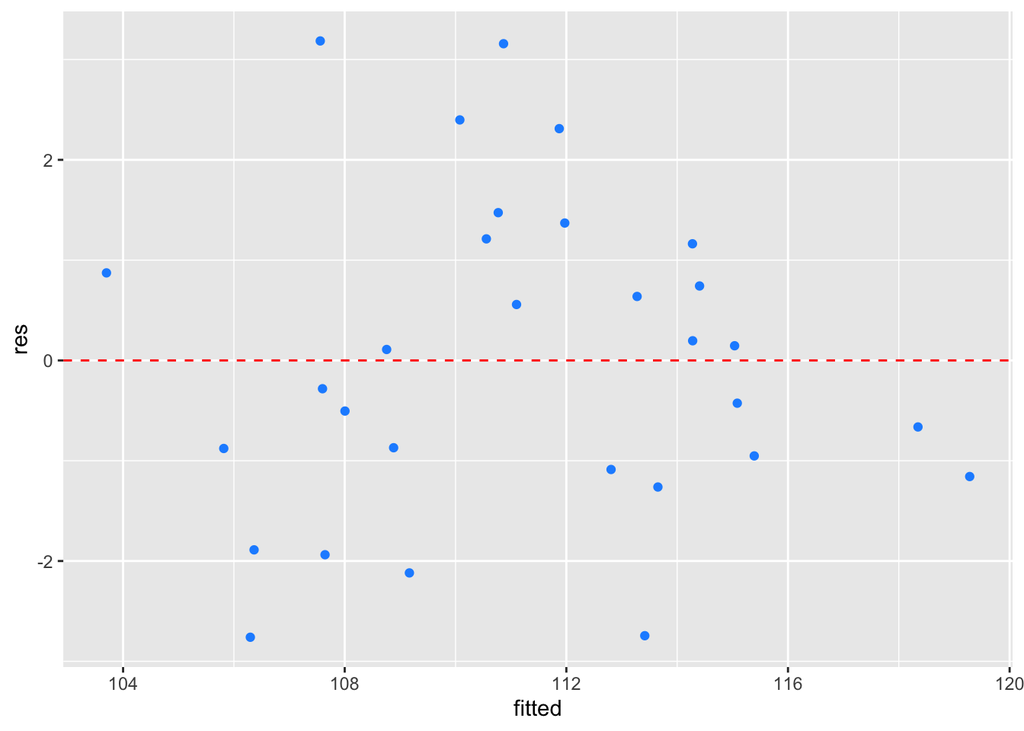

```r
### plotting the data for homescedasticity
res <- residuals(fit)
fitted <- predict(fit)

ggplot(data = NULL, aes(x = fitted, y = res)) +
  geom_point(colour = "dodgerblue") +
  geom_hline(yintercept = 0, colour = "red", linetype = "dashed")
```

There does not appear to be evidence of heteroscedasticity, therefore the data is homoscedastic.

### Normality.

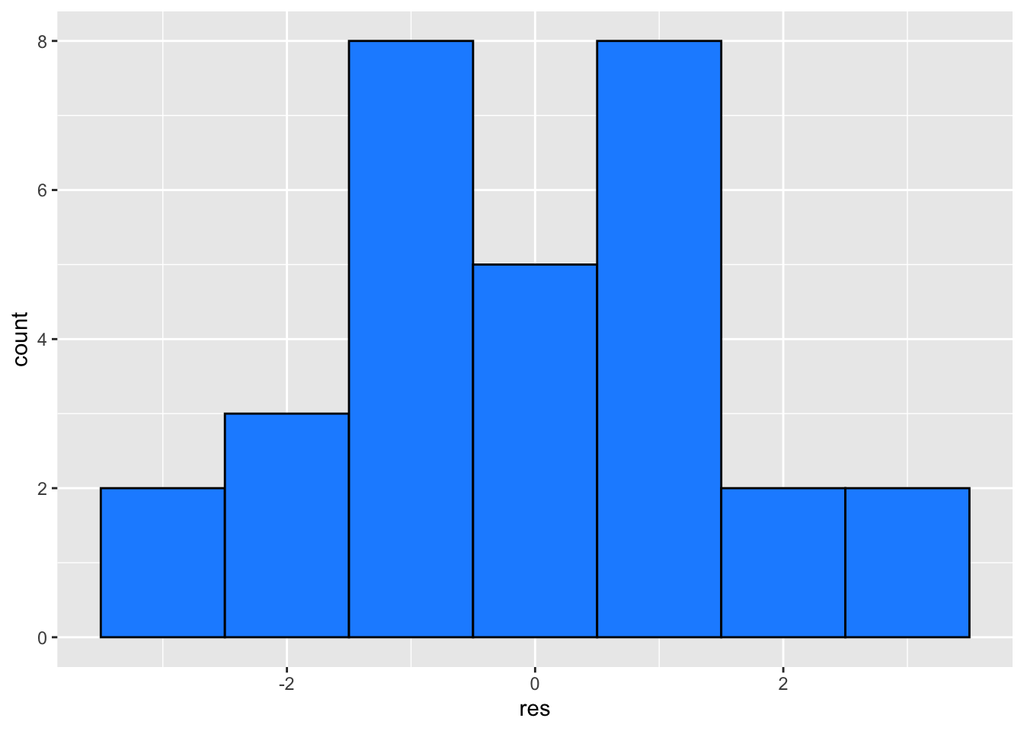

```r
### plotting the residuals to confirm normal distribution
ggplot(data = NULL, aes(x = res)) +
  geom_histogram(colour = "black", fill = "dodgerblue", binwidth = 1)
```

Histogram looks fairly normal, some long tails though at either end

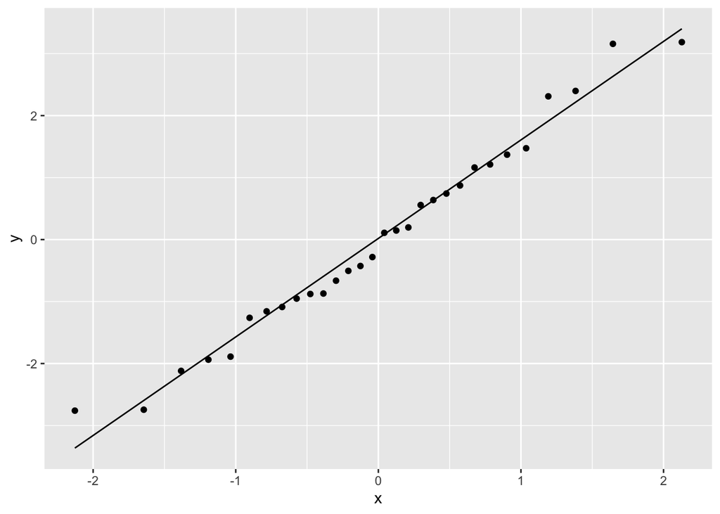

```r
### Using the QQ plot to check for normality as well
ggplot(data = NULL, aes(sample = res)) +
  stat_qq() + stat_qq_line()
```

Observations lie roughly along the line.

### Linearity

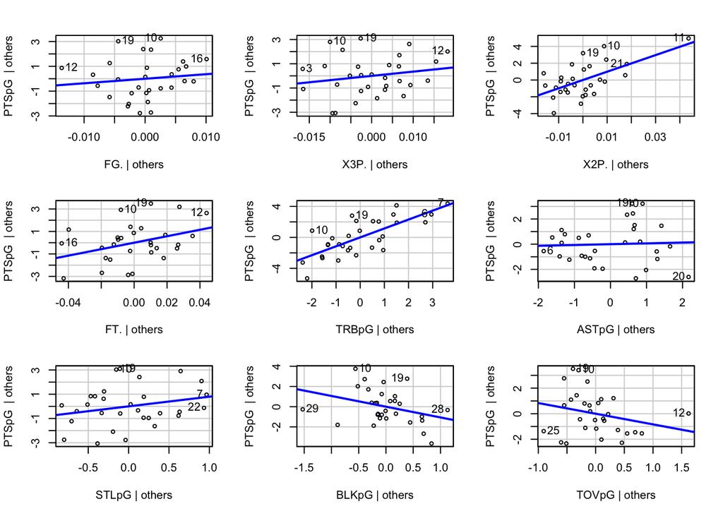

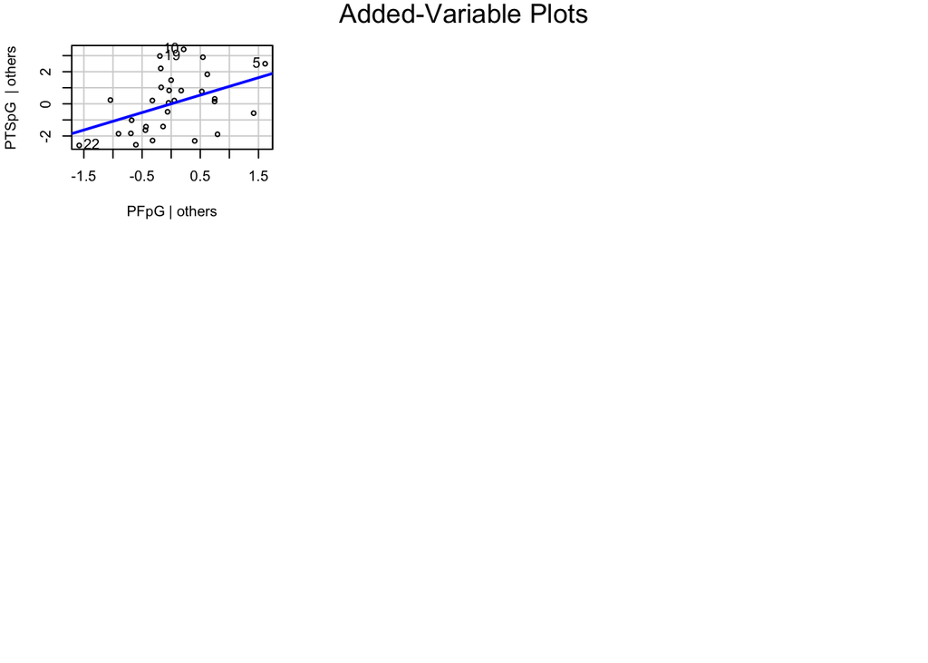

```r
### using avPlots for checking linearity
car::avPlots(fit)
```

### Multicollinearity - Visual

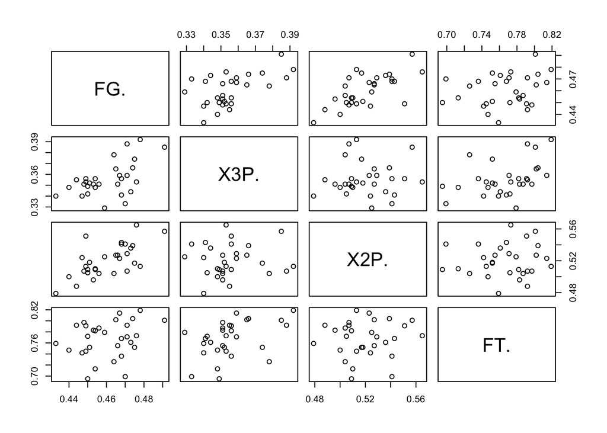

```r
### Plotting for the first few variables
pairs(formula = ~ FG. + X3P. + X2P. + FT. , data = model_dataframe)
```

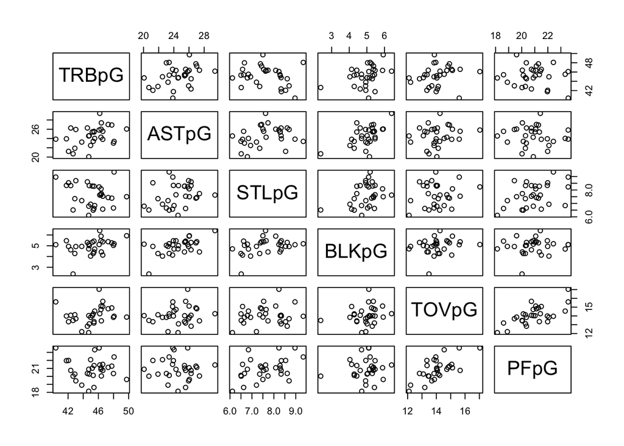

```r
### Plotting for the remaining variables
pairs(formula = ~ TRBpG + ASTpG + STLpG + BLKpG + TOVpG + PFpG , data = model_dataframe)
```

### Multicollinearity - Statistical

```r
### Using the vif function from car library
car::vif(fit_2)
```

```
##       FG.      X3P.      X2P.       FT.     TRBpG     ASTpG     STLpG     BLKpG
## 11.987358  5.415880  6.833983  3.147803  2.161535  4.743041  3.448062  1.994917
##     TOVpG      PFpG
##  6.258502  3.863562
```

Based on the above results we can clearly observe there are values which are greater than 1 therefore there exisits multicollinearity in the variables

From coorelation plot above and VIF measures above we understood that FG., X3P., ASTpG, TOVpG and PFpg have high multicollinearity (X3P. was removed instead of X2P. because X2P. had higher explanatory significance in previous models)

```r
### Building the third and final multiple linear model for PTSpG
fit_3 <- lm(PTSpG ~ X2P.+ FT.+ TRBpG + STLpG + BLKpG, data = filtered_model_dataframe)

### Viewing the summary
summary(fit_3)
```

```
##
## Call:
## lm(formula = PTSpG ~ X2P. + FT. + TRBpG + STLpG + BLKpG, data = filtered_model_dataframe)
##
## Residuals:
##     Min      1Q  Median      3Q     Max
## -2.9138 -1.4834 -0.3228  1.3730  4.5814
##
## Coefficients:
##             Estimate Std. Error t value Pr(>|t|)
## (Intercept) -43.2852    20.9821  -2.063  0.05112 .
## X2P.         93.3328    28.4337   3.282  0.00340 **
## FT.          48.7567    14.9800   3.255  0.00363 **
## TRBpG         1.3633     0.2742   4.972 5.63e-05 ***
## STLpG         1.6235     0.6541   2.482  0.02118 *
## BLKpG        -1.1122     0.7721  -1.441  0.16381
## ---
## Signif. codes:  0 '***' 0.001 '**' 0.01 '*' 0.05 '.' 0.1 ' ' 1
##
## Residual standard error: 2.239 on 22 degrees of freedom
## Multiple R-squared:  0.7669, Adjusted R-squared:  0.7139
## F-statistic: 14.47 on 5 and 22 DF,  p-value: 2.486e-06
```

This model has an acceptable R-Squared and further the P-Values for the predictors indicate that they are significantly different from Zero. Especially X2P., FT., TRBpG and STLpG.

```r
### checking for any remaining multicollinearity
car::vif(fit_3)
```

```
##     X2P.      FT.    TRBpG    STLpG    BLKpG
## 1.748510 1.309992 1.786816 1.655124 1.825307
```

All vif values are quite close to 1 (some are close to 2) so does not appear to be any multicollinearity influencing the standard errors of the coefficients much better than previous models.

# 5. Player recommendations

## Background for player selection

In basketball, “per-possession” or “per-100 possessions” is a statistic akin to “per-plate-appearance” in baseball. Because basketball games often feature many more possessions than plate appearances in baseball, adjusting statistics on a per-possession basis rather than a per-game one is more suitable. 1.

Even if the two teams have identical levels of skill, a team that plays at a fast tempo and has many possessions per game will generally have greater statistics than a team that plays at a slow pace and has fewer possessions per game. Adjusting statistics on a possession-by-possession basis provides for more accurate team comparisons. 1. 2.

Individual player statistics in basketball are frequently adjusted to per-100 possessions to accommodate for variances in pace and playing time between players. This enables more precise comparisons of player performance. 2.

These are some measures that can be used in basketball to compare the performance of a team or a player.

True shooting percentage: This is a shooting efficiency metric that accounts for field goals, 3-point field goals, and free throws. It is determined by dividing the total number of points scored by the total number of field goals, 3-point field goals, and free throw attempts.

Rebounding rate: The number of rebounds a team or player receives per possession. The total number of rebounds is divided by the total number of possessions.

Turnover rate: The number of turnovers committed by a team or player each possession. The total number of turnovers divided by the total number of possessions yields this figure.

Steal rate: The number of steals a team or player gets each possession. The total number of steals divided by the total number of possessions yields this figure.

Efficiency: measurement of how many points a team or individual scores per possession. It is computed by dividing the total number of possessions by the total number of points scored.

Assist rate: This is a metric that measures how many assists a team or player receives per possession. The total number of assists divided by the total number of possessions yields this figure.

These measurements, in addition to scoring, can help to present a more full picture of team or player performance by taking into consideration elements such as efficiency, rebounding, and turnovers. 1. 2.

## Player PTSpG Model Generation

Calculating the metrics for each player to predict the points they would score if all the players in the team was that single player

```r
### creating player model dataframe to fit to the model fit_3
player_model_data <- player_statistics_salary_combined %>% mutate(TRBpG = TRB/G,
                                                                  STLpG = STL/G,
                                                                  BLKpG = BLK/G) %>%
  select(c(X2P., FT., TRBpG, STLpG, BLKpG))

player_statistics_salary_combined <- player_statistics_salary_combined %>%
  mutate(exp_PTSpG = predict(fit_3, newdata = player_model_data))
```

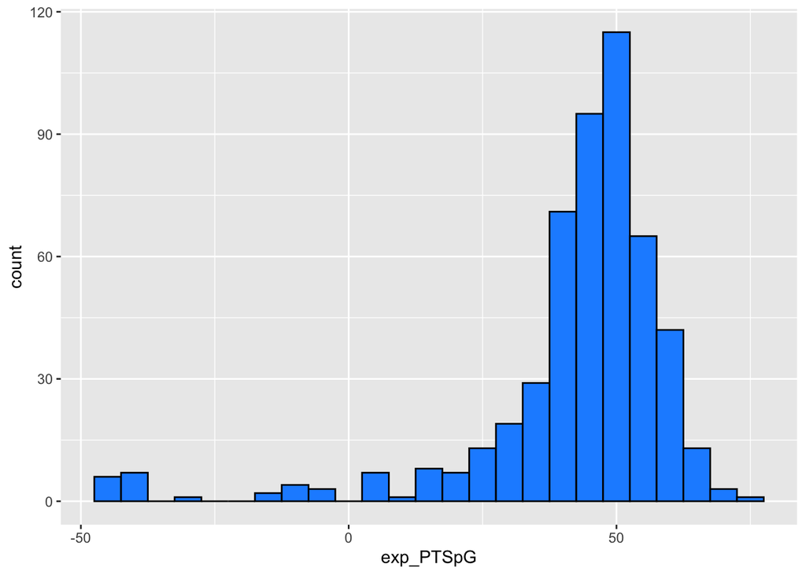

```r
### looking at the distribution for predictions PTSpG
player_statistics_salary_combined %>%
  ggplot(aes(x = exp_PTSpG)) +
  geom_histogram(binwidth = 5, colour = "black", fill = "dodgerblue")
```

We can roughly see that the predictions are normal with a left skew.

## Getttin the playing positions which are unique in the dataframe

```r
unique(player_statistics_salary_combined$Pos)
```

```
##  [1] "PF"    "PG"    "SF"    "C"     "SG"    "PF-SF" "PF-C"  "SF-SG" "SG-SF"
## [10] "SG-PF" "C-PF"
```

## PG - Choosing a player for Point Guard

Using expected PTSpG and mean number of minutes played, the list of players in descending order are.

```r
PG_players <- player_statistics_salary_combined %>% filter( Pos %in% c("PG")) %>%
  filter(MP > quantile(player_statistics_salary_combined$MP, 0.75)) %>%
  select(c(player_name, Pos, Age, MP, Tm, salary, exp_PTSpG)) %>%
  arrange(desc(exp_PTSpG))

PG_players
```

```
##                player_name Pos Age   MP  Tm   salary exp_PTSpG
## 1             James Harden  PG  29 2867 HOU 30570000  60.36696
## 2            Stephen Curry  PG  30 2331 GSW 37457154  59.42803
## 3             Kyrie Irving  PG  26 2214 BOS 20099189  57.77372
## 4             Eric Bledsoe  PG  29 2272 MIL 15000000  55.93005
## 5           Damian Lillard  PG  28 2838 POR 27977689  55.38945
## 6               Kyle Lowry  PG  32 2213 TOR 32700000  53.44223
## 7         Ryan Arcidiacono  PG  24 1961 CHI  1349383  53.39966
## 8               Chris Paul  PG  33 1857 HOU 35654150  52.52422
## 9              Ben Simmons  PG  22 2700 PHI  6434520  52.26609
## 10        Tomas Satoransky  PG  27 2164 WAS  3129187  51.79080
## 11            Kemba Walker  PG  28 2863 CHO 12000000  51.53203
## 12       Russell Westbrook  PG  30 2630 OKC 35665000  51.31841
## 13             DJ Augustin  PG  31 2269 ORL  7250000  51.03518
## 14            Monte Morris  PG  23 1970 DEN  1349383  49.99385
## 15         Darren Collison  PG  31 2143 IND 10000000  49.57989
## 16             Mike Conley  PG  31 2342 MEM 30521115  49.47926
## 17            Jamal Murray  PG  21 2447 DEN  3499800  49.29905
## 18       Spencer Dinwiddie  PG  25 1914 BRK  1656092  49.29746
## 19              Trae Young  PG  20 2503 ATL  5363280  47.95710
## 20 Shai Gilgeous-Alexander  PG  20 2174 LAC  3375360  47.81407
## 21             Ricky Rubio  PG  28 1899 UTA 14800000  47.65574
## 22        D'Angelo Russell  PG  22 2448 BRK  7019698  46.76287
## 23          Reggie Jackson  PG  28 2289 DET 17043478  46.70503
## 24            De'Aaron Fox  PG  21 2546 SAC  5470920  44.31180
## 25           Collin Sexton  PG  20 2605 CLE  4073760  43.40153
## 26        Patrick Beverley  PG  30 2137 LAC  5027028  41.60108
## 27             Cory Joseph  PG  27 2063 IND  7945000  39.32132
```

During the 2018/19 NBA season, the Warriors had a total budget of USD 146,291,276, with their starting 5 players accounting for USD 92,915,444, which is 63.51% of the total cap. The Bucks had a total budget of USD 130,988,604, with their starting 5 players accounting for USD 83,657,304, which is 63.87% of the total cap. The Bulls had a total budget of USD 112,598,201, with their starting 5 players accounting for USD 79,627,159, which is 70.72% of the total cap. 3.

For an overall budget of 65% of the total budget or USD 118 Mn. For the top 5 players we will spend a cumulative USD 76.7 Mn. Based on an average player spend of USD 15.2 Mn the player suited for PG will be

```r
PG_players %>% filter(salary<15200000) %>% top_n(1)
```

```
##    player_name Pos Age   MP  Tm   salary exp_PTSpG
## 1 Eric Bledsoe  PG  29 2272 MIL 15000000  55.93005
```

## SG - Choosing a player for Shooting Guard

Using expected PTSpG and mean number of minutes played, the list of players in descending order are.

```r
SG_players <- player_statistics_salary_combined %>% filter( Pos %in% c("SG","SF-SG", "SG-SF", "SG-PF" )) %>%
  filter(MP > quantile(player_statistics_salary_combined$MP, 0.75)) %>%
  select(c(player_name, Pos, Age, MP, Tm, salary, exp_PTSpG)) %>%
  arrange(desc(exp_PTSpG))

SG_players
```

```
##                 player_name   Pos Age   MP  Tm   salary exp_PTSpG
## 1              Devin Booker    SG  22 2242 PHO  3314365  55.80405
## 2              Bradley Beal    SG  25 3028 WAS 25434262  55.69870
## 3  Kentavious Caldwell-Pope    SG  25 2035 LAL 12000000  54.79915
## 4             Malik Beasley    SG  22 1879 DEN  1773840  54.65812
## 5               Jeremy Lamb    SG  26 2250 CHO  7000000  54.31127
## 6              Jimmy Butler SF-SG  29 2185 TOT 19841627  54.08609
## 7              Jrue Holiday    SG  28 2402 NOP 26641111  53.00731
## 8               Buddy Hield    SG  26 2615 SAC  3833760  52.91678
## 9             DeMar DeRozan    SG  29 2688 SAS 27739975  52.57564
## 10          Jordan Clarkson    SG  26 2214 CLE 12500000  52.28015
## 11               Joe Harris    SG  27 2293 BRK  8333333  52.09928
## 12              Zach LaVine    SG  23 2171 CHI 19500000  51.76936
## 13            Klay Thompson    SG  28 2652 GSW 18988725  50.96421
## 14                JJ Redick    SG  34 2379 PHI 12250000  50.92768
```

[output cut: 25 more lines]

Based on the above dataframe and existing budget, the player with a proven track record and flexibility to play two positions is Jimmy Butler.

```r
SG_players[6,]
```

```
##    player_name   Pos Age   MP  Tm   salary exp_PTSpG
## 6 Jimmy Butler SF-SG  29 2185 TOT 19841627  54.08609
```

# SF - Choosing a player for Small Forward

Using expected PTSpG and mean number of minutes played, the list of players in descending order are.

```r
SF_players <- player_statistics_salary_combined %>% filter( Pos %in% c("SF","PF-SF", "SF-SG", "SG-SF")) %>%
  filter(MP > quantile(player_statistics_salary_combined$MP, 0.75)) %>%
  select(c(player_name, Pos, Age, MP, Tm, salary, exp_PTSpG)) %>%
  arrange(desc(exp_PTSpG))

SF_players
```

```
##            player_name   Pos Age   MP  Tm   salary exp_PTSpG
## 1         Kevin Durant    SF  30 2702 GSW 30000000  63.34695
## 2        Kawhi Leonard    SF  27 2040 TOR 23114066  61.33747
## 3          Paul George    SF  28 2841 OKC 30560700  57.00680
## 4         LeBron James    SF  34 1937 LAL 35654150  56.44169
## 5        Nicolas Batum    SF  30 2354 CHO 24000000  55.31747
## 6     Danilo Gallinari    SF  30 2059 LAC 21587579  55.11782
## 7         Jimmy Butler SF-SG  29 2185 TOT 19841627  54.08609
## 8        Mikal Bridges    SF  22 2417 PHO  3557400  53.53815
## 9     Bojan Bogdanovic    SF  29 2573 IND 10500000  53.24842
## 10        Jayson Tatum    SF  20 2455 BOS  6700800  52.63685
## 11     Khris Middleton    SF  27 2393 MIL 13000000  52.53826
## 12         Kelly Oubre    SF  23 1935 TOT  3208630  51.41441
## 13        Trevor Ariza    SF  33 2349 TOT 15000000  50.52476
## 14 Dorian Finney-Smith    SF  25 1985 DAL  1544951  49.49221
## 15         Jae Crowder    SF  28 2166 UTA  7305825  48.46642
## 16          Cedi Osman    SF  23 2444 CLE  2775000  47.86065
## 17     Harrison Barnes PF-SF  26 2533 TOT 24107258  45.12142
## 18     Wesley Matthews SF-SG  32 2091 TOT 19360228  41.34959
## 19      Andrew Wiggins    SF  23 2543 MIN 25467250  39.35469
## 20     Justise Winslow    SF  22 1959 MIA  3448926  39.23754
```

```r
SF_players %>% filter(salary<15200000 & salary > 12000000) %>% top_n(1)
```

```
##       player_name Pos Age   MP  Tm   salary exp_PTSpG
## 1 Khris Middleton  SF  27 2393 MIL 13000000  52.53826
```

# PF - Choosing a player for Power Forward

```r
PF_players <- player_statistics_salary_combined %>% filter( Pos %in% c("PF","PF-SF", "PF-C", "SG-PF", "C-PF")) %>%
  filter(MP > quantile(player_statistics_salary_combined$MP, 0.75)) %>%
  select(c(player_name, Pos, Age, MP, Tm, salary, exp_PTSpG)) %>%
  arrange(desc(exp_PTSpG))

PF_players
```

```
##              player_name   Pos Age   MP  Tm   salary exp_PTSpG
## 1  Giannis Antetokounmpo    PF  24 2358 MIL 24157304  69.46329
## 2          Pascal Siakam    PF  24 2548 TOR  1544951  61.28927
## 3             Jeff Green    PF  32 2097 WAS  2393887  60.51800
## 4          Tobias Harris    PF  26 2847 TOT 14800000  59.44916
## 5        Al-Farouq Aminu    PF  28 2292 POR  6957105  58.13650
## 6          Julius Randle    PF  24 2232 NOP  8641000  57.30659
## 7               Rudy Gay    PF  32 1842 SAS 10087200  56.62870
## 8         Gordon Hayward    PF  28 1863 BOS 31214295  55.10397
## 9            Dario Saric    PF  24 2023 TOT  2526840  54.66380
## 10         Marcus Morris    PF  29 2091 BOS  5375000  54.16377
## 11         Blake Griffin    PF  29 2622 DET 31873932  53.40884
## 12            Kyle Kuzma    PF  23 2314 LAL  1689840  52.97037
## 13        Draymond Green    PF  28 2065 GSW 17469565  52.78693
## 14          Paul Millsap    PF  33 1895 DEN 29230769  51.78286
## 15        Thaddeus Young    PF  30 2489 IND 13764045  51.52732
## 16        Jonathan Isaac    PF  21 1996 ORL  4969080  51.34601
## 17          Jerami Grant    PF  24 2612 OKC  8333333  50.08564
## 18          Aaron Gordon    PF  23 2633 ORL 21590909  49.34935
## 19       Marvin Williams    PF  32 2133 CHO 14087500  48.80808
## 20            Joe Ingles    PF  31 2568 UTA 12545455  48.08764
## 21       Harrison Barnes PF-SF  26 2533 TOT 24107258  45.12142
## 22             PJ Tucker    PF  33 2802 HOU  7959537  42.55524
## 23            Kevin Knox    PF  19 2158 NYK  3744840  34.45744
```

```r
PF_players %>% filter(salary<15200000 ) %>% top_n(1)
```

```
##     player_name Pos Age   MP  Tm  salary exp_PTSpG
## 1 Pascal Siakam  PF  24 2548 TOR 1544951  61.28927
```

# C - Choosing a player for Centre

```r
C_players <- player_statistics_salary_combined %>% filter( Pos %in% c("C", "PF-C", "C-PF")) %>%
  filter(MP > quantile(player_statistics_salary_combined$MP, 0.75)) %>%
  select(c(player_name, Pos, Age, MP, Tm, salary, exp_PTSpG)) %>%
  arrange(desc(exp_PTSpG))

C_players
```

```
##            player_name Pos Age   MP  Tm   salary exp_PTSpG
## 1       DeAndre Jordan   C  30 2047 TOT 22897200  68.54766
## 2          Rudy Gobert   C  26 2577 UTA 23491573  66.43970
## 3   Karl-Anthony Towns   C  23 2545 MIN  7839435  66.42620
## 4         Nikola Jokic   C  23 2504 DEN 25467250  66.01806
## 5         Clint Capela   C  24 2249 HOU 15793104  64.83145
## 6          Joel Embiid   C  24 2154 PHI 25467250  63.44851
## 7       Nikola Vucevic   C  28 2510 ORL 12750000  63.18948
## 8        Anthony Davis   C  25 1850 NOP 25434263  62.71020
## 9        Deandre Ayton   C  20 2183 PHO  8175840  62.31000
## 10          Al Horford   C  32 1973 BOS 28928710  62.30129
## 11       Jarrett Allen   C  20 2096 BRK  2034120  60.64563
## 12         Brook Lopez   C  30 2322 MIL  3382000  60.21041
## 13   LaMarcus Aldridge   C  33 2687 SAS 22347015  59.20619
## 14         Serge Ibaka   C  29 2010 TOR 21666667  58.76951
## 15      Andre Drummond   C  25 2647 DET 25434262  58.74007
## 16         Bam Adebayo   C  21 1913 MIA  2955840  57.88019
## 17        Jusuf Nurkic   C  24 1974 POR 11111111  57.38975
## 18    Montrezl Harrell   C  25 2158 LAC  6000000  55.02012
## 19        Steven Adams   C  25 2669 OKC 24157304  50.98854
## 20          Marc Gasol   C  34 2436 TOT 24119025  50.50978
## 21        Myles Turner   C  22 2119 IND  3294994  49.33418
## 22 Willie Cauley-Stein   C  25 2213 SAC  4696874  48.10790
```

We are gonna use the entire remaining budget to obtain a Centre player with reputed playmaking.

```r
C_players[8,]
```

```
##     player_name Pos Age   MP  Tm   salary exp_PTSpG
## 8 Anthony Davis   C  25 1850 NOP 25434263   62.7102
```

# 6. Summary

For this project, I was given the task of selecting the best five starting players for the Chicago Bulls basketball team for the upcoming season while staying within a budget of USD 118 million for player contracts. I started by obtaining NBA player data for the past season and cleaning it up by removing unnecessary columns and missing values.

Using visualizations, I explored the data to gain insights into the relationships between different variables and player performance. I then performed a multiple linear regression analysis to create a model that could predict a player’s score based a model that was built for a team on their performance statistics. Based on this model, I identified the players who were likely to score the highest and chose the best player for each position while considering their expected points, salaries and basketball background domian knowledge.

The following players were selected for the Chicago Bulls basketball team. - Eric Bledsoe as the Point Guard - Jimmy Butler as the Shooting Guard - Khris Middleton as the Small Forward - Pascal Siakam as the Power Forward - Anthony Davis as the Center

I am confident that these players will perform well on the court and help improve the team’s ranking in the next season.

# 7. Reference List

1. Shea SM, Baker CE. Basketball analytics: Objective and efficient strategies for understanding how teams win. Lake St. Louis, MO: Advanced Metrics; 2013.
2. Oliver D. Basketball on paper: Rules and tools for performance analysis. Washington, D.C.: Potomac Books, Inc.; 2011.
3. These are the 2018/19 salaries of Chicago Bulls players [Internet]. HoopsHype; [cited 2023 May 9]. Available from: https://hoopshype.com/salaries/chicago_bulls/2018-2019/